# Render : Déploiement App Dash

# 1. Présentation

Objectif : Déployer un application dash sur un serveur (mise en production)

Intérêt : Diffuser votre application dash via un lien (URL)

Outils : Le package python dash-tools, le site Github et la plateforme gratuite Render

Pré-requis :

Une application dash fonctionnelle

Un compte sur Github (https://github.com/)

Un compte sur Render (https://dashboard.render.com/login)

⚠ Remarque : Créer d’abord votre compte sur Github puis créer votre compte sur Render en utilisant votre compte Github.

[figure not shown]

# 2. Installer dash-tools

Procédure d’installation du package dash-tools dans un environnement virtuel :

pip install dash-tools  
cd RootProject  
git init  
dashtools gui

# Installer le package dash-tools  
# Se placer à la racine du projet  
# Initialiser un dépôt local git  
# Ouverture de l’interface Dash Tools

# 3. Interface Dash Tools

[figure not shown]

# 4. Initialisation du pipeline

Cliquer sur Deploy

Copier le chemin vers la racine du projet dans vos répertoires dans File Explorer, puis cliquer sur Open File

[figure not shown]

À droite de l’interface, on observe un ensemble de pré-requis pour pouvoir utiliser le pipeline Deployement Requirements

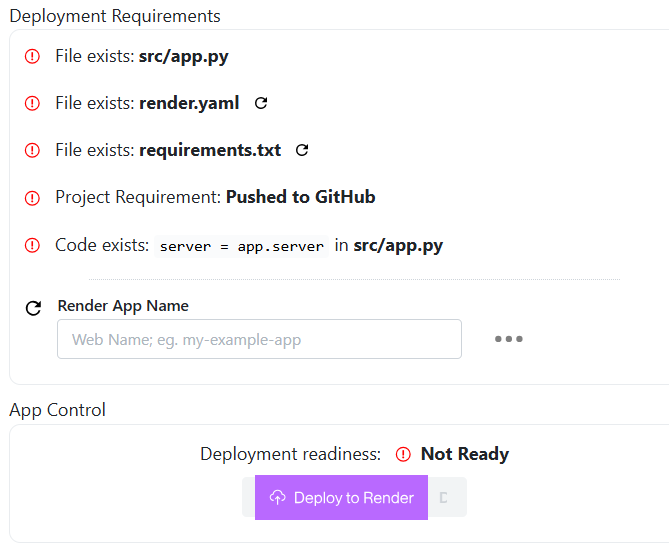

# 5. Qu’est-ce qu’un pipeline ?

Un pipeline dans le cadre du déploiement d’une application Dash avec Render (ou tout autre service similaire) est une suite automatisée d’étapes qui permet de :

1. Préparer le code : Vérifier et préparer le code source de votre application.
2. Construire l’application : Installer les dépendances et configurer l’environnement pour exécuter l’application.
3. Déployer : Transférer l’application sur un serveur et la rendre disponible aux utilisateurs via une URL ou un domaine.

Étapes principales d’un pipeline pour une application Dash avec Render :

1. Récupération du code : Render récupère automatiquement votre application depuis un dépôt Git (par exemple, GitHub ou GitLab).
2. Installation des dépendances : Render lit un fichier comme *requirements.txt* pour installer les bibliothèques nécessaires.
3. Configuration et démarrage : Render exécute une commande, comme *gunicorn app:server*, pour lancer l’application Dash.
4. Mise en ligne : Le serveur de Render héberge l’application et la rend accessible via une URL publique.

En résumé, un pipeline de déploiement est une séquence structurée d’étapes automatisées qui simplifie et fiabilise le processus de mise en ligne de votre application.

# 6. Pipeline requirements

1. src/app.py : Créer un sous-répertoire nommé src à la racine du projet et déplacer le fichier app.py dans ce sous-répertoire
2. Render App Name : Créer un nom d’application avant de générer les autres fichiers
3. render.yaml & requirements.txt : Générer successivement ces fichiers directement sur l’interface en cliquant sur la flèche arrondie. Ces opérations peuvent prendre du temps, se référer à l’encadrer Command Output pour suivre le déroulement

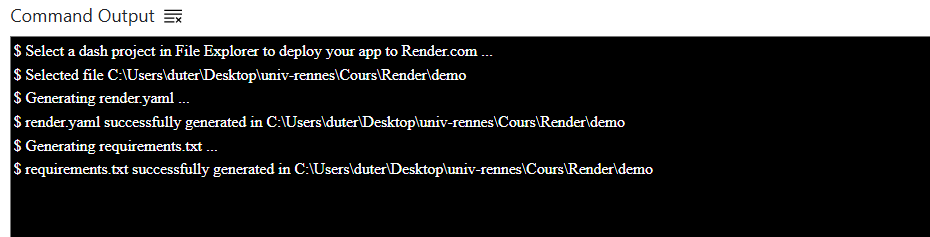

4. app.server : Ajouter la ligne *server = app.server* juste après la création de l’objet *Dash(**name**)* dans le script app.py

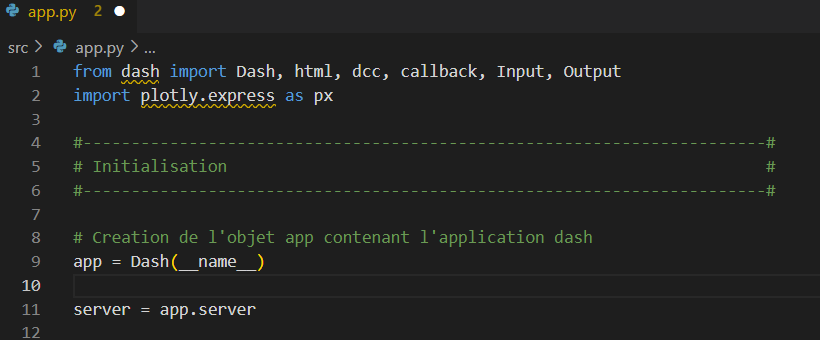

5. Pushed to Github :
   - Créer un nouveau dépôt sur Github : *Profil Account* > *Repositories* > *New*

[figure not shown]

   - Ce nouveau dépôt doit être public et initialisé sans Readme

[figure not shown]

   - Ouvrir un terminal Git Bash et se placer à la racine du projet
   - Copier les commandes de la rubrique … or create a new repository on the command line sur Github (cf. capture ci-dessous) et les exécuter dans le terminal

[figure not shown]

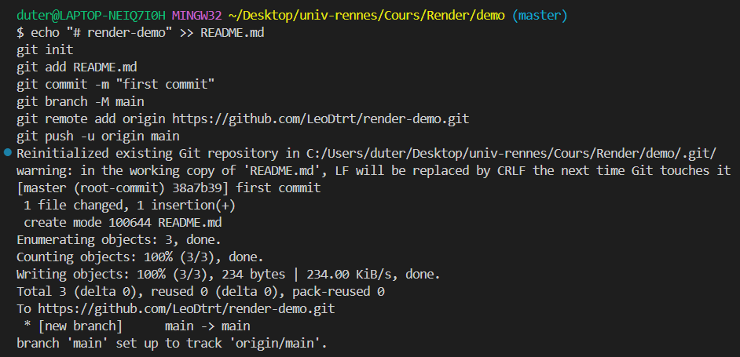

   - L’exécution de ces commandes permet d’effectuer le Pushed to Github avec l’ajout du Readme

[figure not shown]

   - ⚠ Insuffisant ! En l’état, le dépôt public Github ne contient que le Readme

[figure not shown]

   - Il faut ajouter le reste du projet et le pousser dans le dépôt public

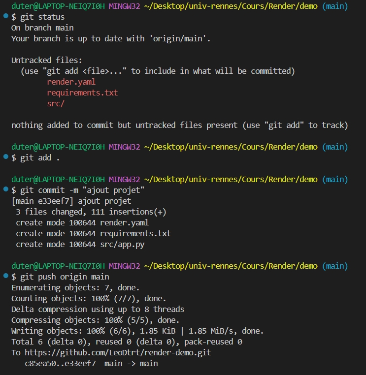

   - Une fois le projet ajouté, vérifier que tous les fichiers sont présents dans le dépôt sur Github :

[figure not shown]

   - Enfin, retourner sur l’interface Dash Tools et cliquer sur Deploy to Render

[figure not shown]

# 7. Déploiement avec Render

- Ouverture de l’interface https://dashboard.render.com via le bouton Deploy to Render

[figure not shown]

- Ajouter un Blueprint Name, puis sélectionner la branche main (par défaut) et cliquer sur Deploy Blueprint

[figure not shown]

- Il peut arriver que le déploiement échoue

[figure not shown]

- Voici quelques pistes pour le débug:
  - Vérifier que vous avez bien tenté de déployer sur la bonne image de vos scripts (commit)
  - Vérifier que vous utiliser la bonne version de Python (ex : 3.12.2)
  - Vérifier la compatibilité des versions de package mentionnées dans le fichier *requirement.txt*

[figure not shown]

- Une fois les modifications effectuées, pousser les modifications sur le dépôts sur Github et cliquer sur *Manual Deploy > Deploy latest commit*
- Si pas de message d’erreur, alors l’application est déployée avec succès et vous pouvez cliquer sur le lien https pour ouvrir l’app :

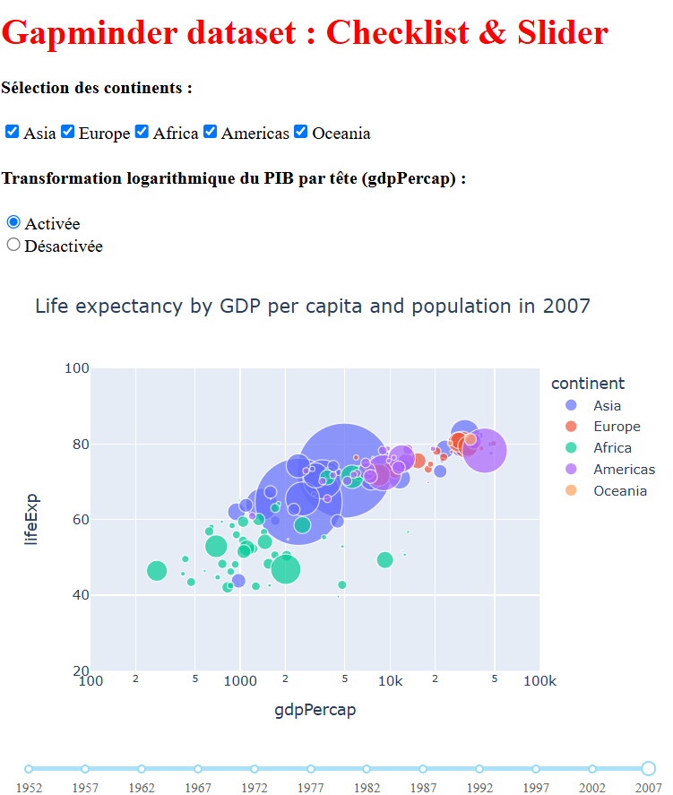

Possible de redeployer l’application manuellement

Faire les modifications en local sur les scripts de l’application

Ajouter les modifcations et les pousser sur le dépôt public Github (git add + git commit + git push)

Bien vérifier que la branche main du dépôt Github est à jour des modifications

Le déploiement ne se fait que sur l’image du main de votre projet sur Github

Retourner sur l’interface de Render, et cliquer sur *Manual Deploy > Deploy latest commit*